# Changes in the Geography of Chinese Production

Group 5 (Justin Han, Wendy Liang, Rachel Paresa, Alec Raines, Denny Wang)

January 25, 2019

## Part 1 - Understanding our Data

### How China is Governed

China is the most populous country in the world. Due to this it requires an extensive governmental network to manage its citizens across its 3.7 million square miles of land. To conquer this, China has four administrative divisions:

- China’s Administrative Divisions ( [Provinces of China](https://en.wikipedia.org/wiki/Provinces_of_China#Types_of_provincial-level_divisions))
  - 22 Provinces
  - 5 Autonomous Regions
  - 4 Centrally Administered Municipalities
  - 2 Special Administrative Regions
  - 1 Province

Cities such as Beijing, Shanghai, Tianjin, and Chongqing are municipalities.

> In China, municipalities directly under the juristiction of the central government are under direct leadership of the central government, and they are equal to the provincial level in terms of administrative hierarchy. These municipalities directly under the juristiction of the central government have the characters of both provinces and independent cities. They have special administrative powers that other normal cities do not have, and they can enjoy special policies and preferential treatment that are absent to other cities ( “13.2.2.1” ).

Looking deeper into the dataset, some readers may find that there are regions or locations in China that are missing off of this dataset. Some of those places include Taiwan, Hong Kong, and Macao. This stems from the “One Country, Two Systems” plan China made in 1984. China deemed that regions that operated independently before this time, would cease to be independent regions, and fall under the Chinese borders. However, Macao and Hong Kong were capitalist regions that contradicted China’s socialist system. Therefore, these would fall under Chinese soverignty, and be deemed as Special Administrative Regions. These regions social, economic, legal systems, and way of life would remain unchanged, it would only fall within Chinese territory ( [One Country, Two Systems](http://www.china.org.cn/english/features/dengxiaoping/103372.htm)). The difference in systems results in statistics from these locations to be not in the same dataset as the rest of China. Also, it wasn’t until China’s 2010 Census for data to be collected and hosted from China. You can find data on these Special Administrative Regions on the [National Bureau of Statistics of China](http://www.stats.gov.cn/english/Statisticaldata/AnnualData/). When searching for data, Speical Administrative Regions will not be with the rest of China’s statistics, they will be located at the end of the data book in Chapters 26 (Hong Kong), 27 (Macao), 28 (Taiwan).

### Issues with Chinese Statistics

China obtains national statistics from the Chinese Census that occurs every 5 years. It is a large undertaking that “employs 3 million people, counted more than 8 million enterprises and estimated a GDP of almost 59 trillion yuan ($9.5 trillion)”. However with this many people working on such a large venture, there are many scandals surrounding the census on the basis of incorrect data being collected. The Chinese National Bureau of Statistics “draw on the data reported directly to it by large enterprises (those with annual revenues of over 20 million yuan). But it remains largely in the dark about smaller firms.” A majority of these large companies are owned by the state, which can lead to misrepresentation when it comes time to submitting statistics. Issues also arrive when it comes to the pure size of China, “industrial profits recently reported by large enterprises were lower than reported last year because some under-sized and double-counted firms were purged from the sample”. The Census is also a very political subject. This data become public to all outside governments, so the census is a representation of how the country is doing. This means that “census-takers succumb to political pressure, faking information” to try and bump up the statistics of their own country ( [The critics it deserves; Free Exchange](https://www.economist.com/finance-and-economics/2018/07/07/chinas-statistics-are-bad-many-criticisms-of-them-are-worse)). All of these considered, data collected off of the Chinese National Bureau of Statistics should be double checked for accuracy if possible due to multiple reports of faking data. Especially within the more recent times, data has been reported to be faked from the 90s and even more recently from the 2008 Financial Crisis to present day ( Hsu, Sara). Furthermore, private firms who are less likely to bend to political pressure are a key source to go to for statistics. For example, the All China Data Center is a firm who aggregates data from various sources to ensure the most accurate data available.

### Citations

“13.2.2.1 Green Investment of Four Municipalities Directly Under the Jurisdiction of the Central Government.” China Green Development Index Report 2011, by Xiaoxi Li and Jiancheng Pan, Springer Science & Business Media, 2012, p. 337.

Hsu, Sara. “China’s GDP Numbers: Can We Trust The Data?” Forbes, Forbes Magazine, 23 Jan. 2017, www.forbes.com/sites/sarahsu/2017/01/23/chinas-gdp-numbers-can-we-trust-the-data/#50ccad006577.

[“One Country, Two Systems.” China.org.cn, China.org, www.china.org.cn/english/features/dengxiaoping/103372.htm.](http://www.china.org.cn/english/features/dengxiaoping/103372.htm)

[“Provinces of China.” Wikipedia, Wikimedia Foundation, 22 Jan. 2019, en.wikipedia.org/wiki/Provinces_of_China#Types_of_provincial-level_divisions.](https://en.wikipedia.org/wiki/Provinces_of_China#Types_of_provincial-level_divisions)

[“The critics it deserves; Free exchange.” The Economist 7 July 2018: 63(US). Business Insights: Global. Web. 23 Jan. 2019.](https://www.economist.com/finance-and-economics/2018/07/07/chinas-statistics-are-bad-many-criticisms-of-them-are-worse)

## Part 2 - Exploring and Visualizing the Data

### 2.1 Exploring the Data

Across all the provinces, there was an increase in output from 1949 to 2017. What was very interesting was that around 1990, the output across all provinces increased at a seemingly exponential rate. Where in 1949, the output of Beijing was 1.47 to 625.90 in 1990 and 18087.27 in 2016. It is important to note that 1950 started the era of American consumerism and producing goods through outsourcing labor and factories in foreign countries, such as China. This may explain the trend why so the output so dramatically increased.

One interesting thing was that the number of enterprises, take Beijing for example, was very high in 1949 at 21055 and over time increased, but then dramatically decreased to 3574 in 1956. As our professor mentioned, that over time certain enterprises got acquired and others merged which may be reflective of the trend in Beijing.

Additionally, as you look through the dataset, you’ll notice that there is quite a bit of missing data that are denoted as *NA*. In a way, this makes it more difficult to visualize the data. For instance, certain graphs will have missing data points that can potentially cause some misinterpretation and/or misrepresentation of the data. One example of this is in the Output by Province (2000-2017) visualization. You can clearly see gaps between the lines.

### 2.2 Visualizing the Data

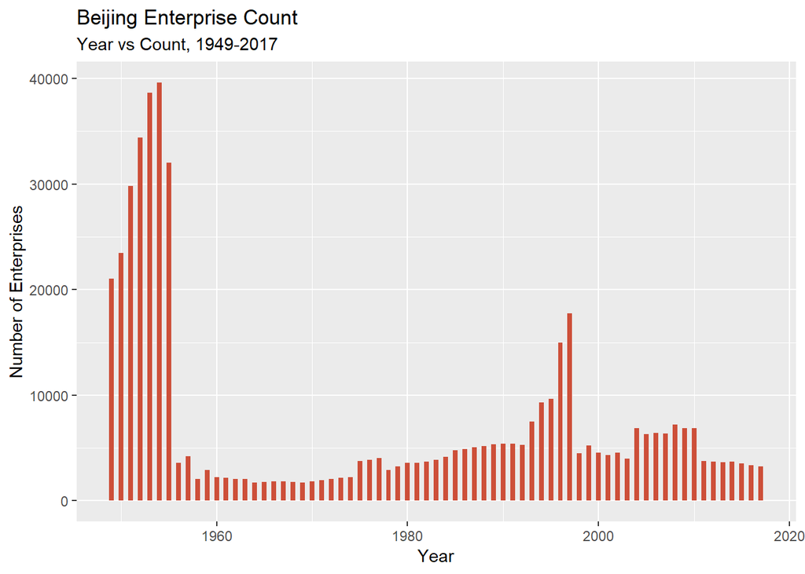

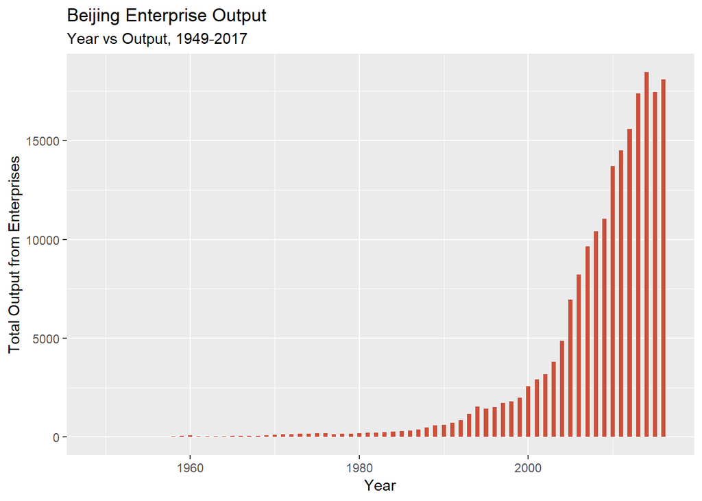

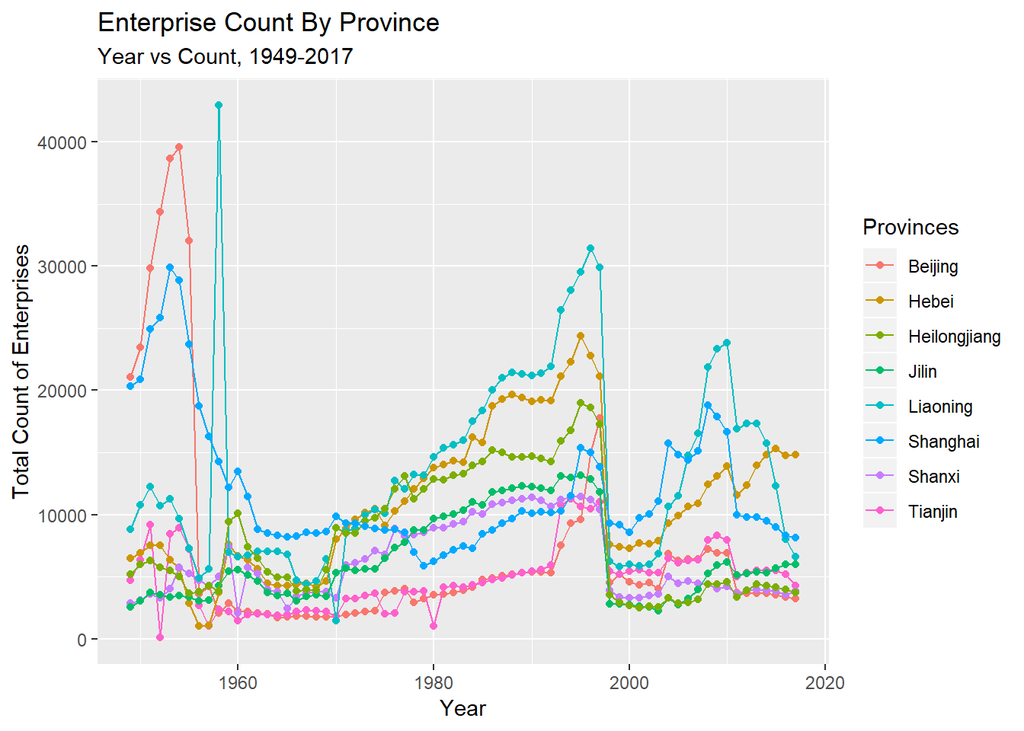

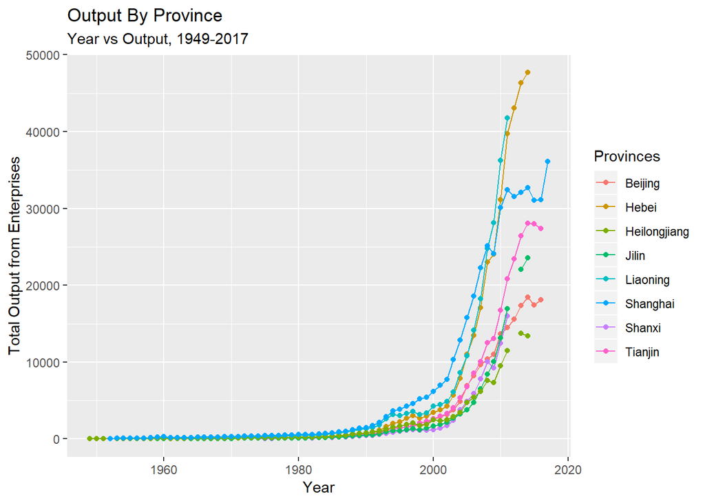

[figure not shown]

[figure not shown]

## Part 3 - Modifying the Data

### 3.1 Output Ratios

Here we have output ratio comparisons of Liaoning, Shandong, and Shanghai in contrast with Guangdong. These four provinces lives along China’s east coast from the north to the south end. In terms of size, Shanghai stands as the smallest province among the four.

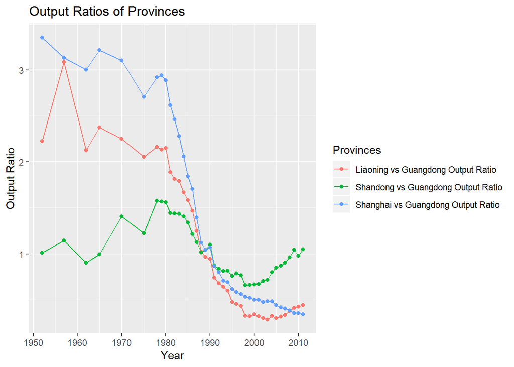

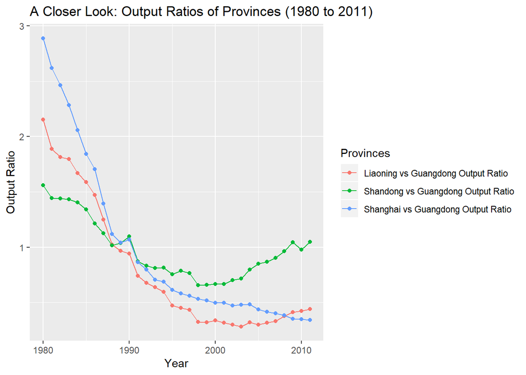

### 3.2 Enterprise & Output

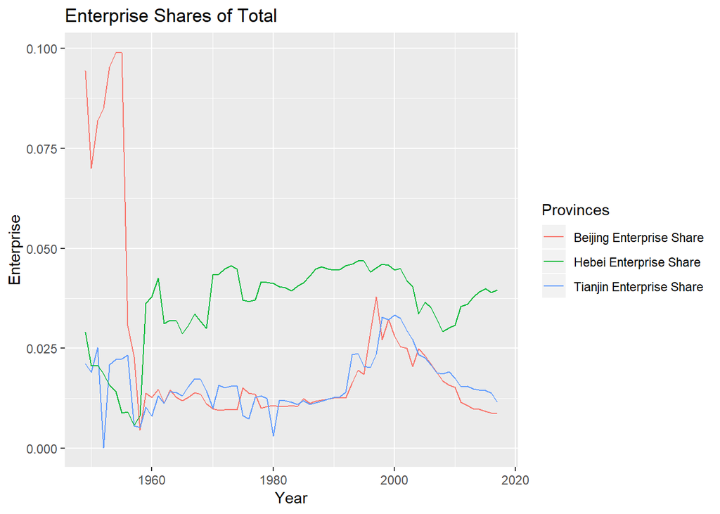

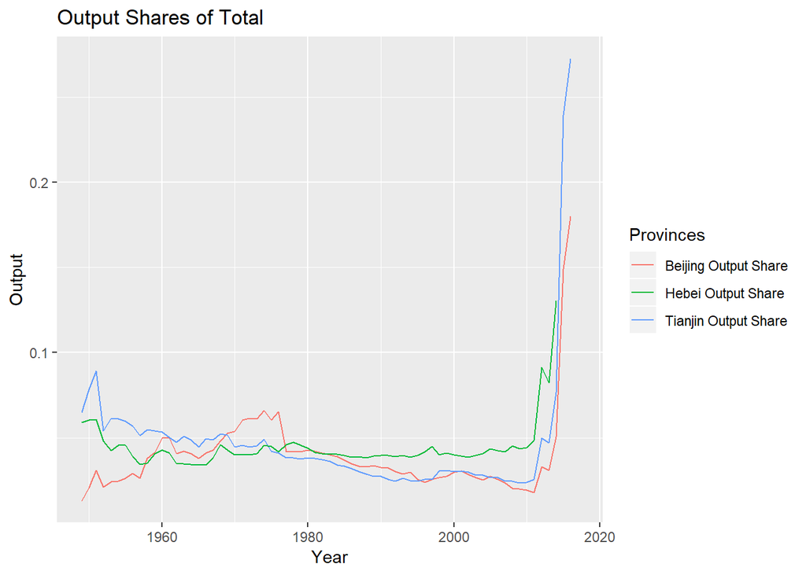

### 3.3 Output/Enterprise

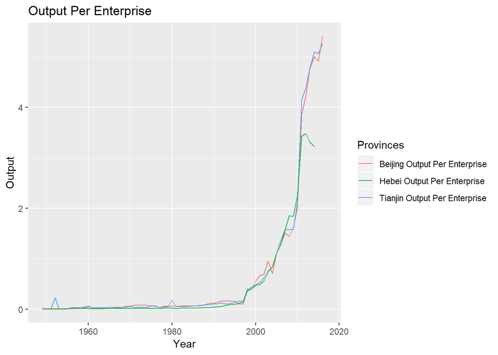

For the Output Per Enterprise graph, it represents data for the same provinces, but it shows the amount of output per enterprise for each province throughout the years. This graph explains the results of the previous two graphs because it shows how incredibly low each enterpises output was until around 1995 where it started to dramatically increase until the last year the data was collected. This explains the increases in output compared to the national output total despite the decrease in enterprises for Beijing and Tianjin. For Heibei, their output per enteprise did not increase as much as the other two and actually starts to fall off at the end which is why that despite their higher enterprise share then the other two, their output share is less. These changes could be due to enterprises becoming more efficient and productive due to a number of reasons like technology, policy, economy, etc. Another factor could be the number of enterprises have decreased due to other enterprises outcompeting or consolidating them and thus increasing their individual outputs despite the decrease in enterprises.

### 3.4 Population

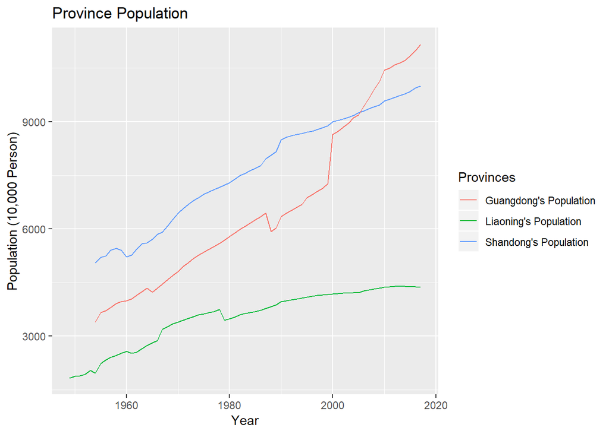

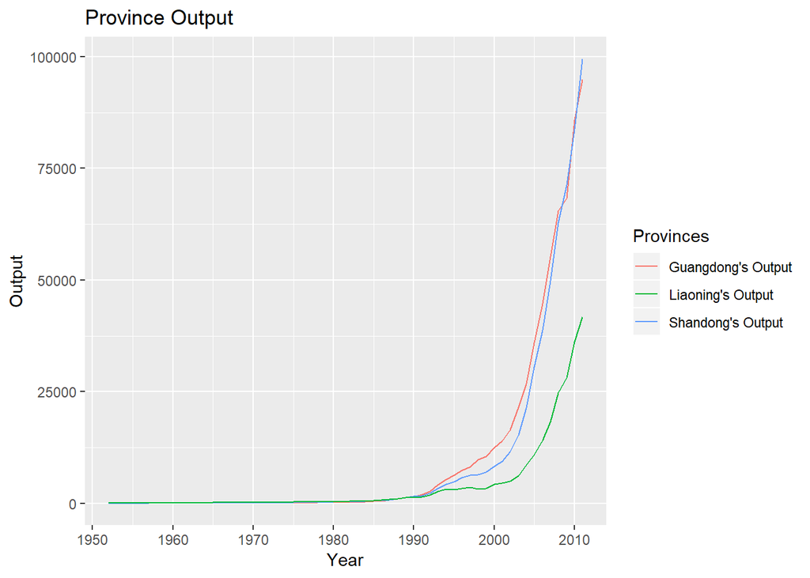

From the graphs above, we can see that Guangdong and Shandong’s output lines follow closely together as it both rises significantly more than Liaoning’s. Similarly, although all three provinces are increasing in population growth, Liaoning’s population starts to slow down in the 2000’s while Guangdong and Shandong’s population not only follows closely, but also intersects near 2005. These similarities of ratio in comparison to Liaoning might have a correlation in that output growth trends can be reflected in the population growth trends for all three provinces.

### 3.5 Relationships

Starting out with, the first chart below graphs all the enterprise values of each province from 1949 to 2017. We can notice that although Shandong and Guangxi starts out at the highest, they both drop drastically around 1955. As we take a closer look in the 2000’s, notice that the provinces of Guangdong, Jiangsu, Shandong, and Zhejiang take a sudden rise more than the other provinces with enterprise values that stay below 25,000. This sudden increase in contrast with the other provinces might be due to their locations with one another as visualized in the map close up.

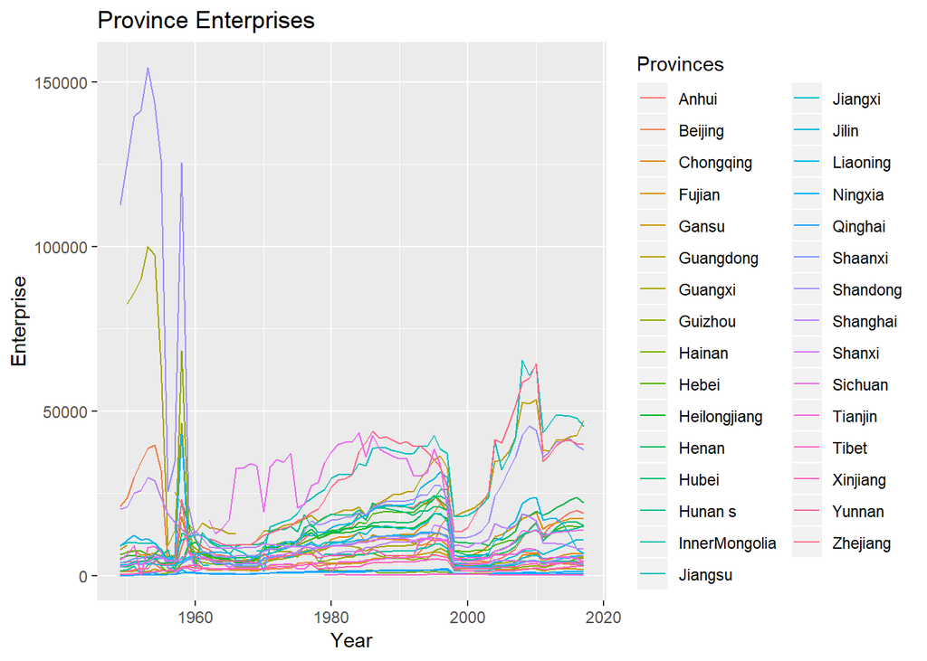

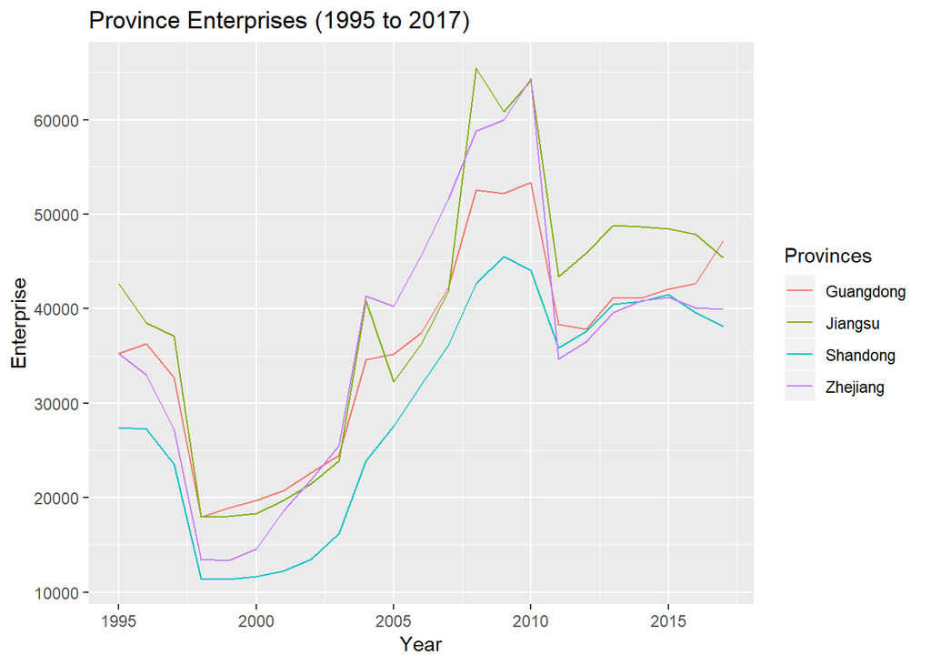

The population of these provinces could also have correlation in the sudden increase in enterprise growth.

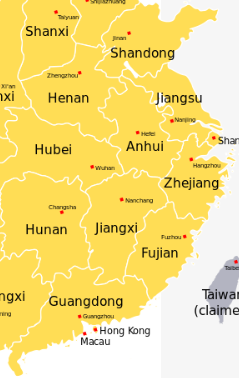

### 3.6 Aggregate

Data is aggregated for each region in China.

- North China - Beijing, Tianjin, Hebei, Shanxi, Inner Mongolia
- Northeast China - Liaoning, Jilin, Heilongjiang
- East China - Shanghai, Jiangsu, Zhejiang, Anhui, Fujian, Jiangxi, Shandong
- South Central China - Henan, Hubei, Hunan, Guangdong, Guangxi, Hainan
- Southwest China - Chongqing, Sichuan, Guizhou, Yunnan, Tibet,
- Northwest China - Shaanxi, Gansu, Qinghai, Ningxia, Xinjiang

**Aggregated Enterprise Data**

|  | Year | North_China_Enterprise | NorthEast_China_Enterprise | East_China_Enterprise | SouthCentral_China_Enterprise | Southwest_China_Enterprise | Northwest_China_Enterprise |
| --- | --- | --- | --- | --- | --- | --- | --- |
| 28 | 2006 | 31078 | 20959 | 153956 | 70580 | 17603 | 7785 |
| 29 | 2007 | 31464 | 23712 | 174006 | 79863 | 19719 | 8004 |
| 30 | 2008 | 36010 | 31525 | 221703 | 101707 | 25928 | 9240 |
| 31 | 2009 | 36800 | 33708 | 224027 | 103803 | 26049 | 9977 |
| 32 | 2010 | 37609 | 34609 | 232633 | 109967 | 27495 | 10559 |

**Aggregated Output Data**

|  | Year | North_China_Output | NorthEast_China_Output | East_China_Output | SouthCentral_China_Output | Southwest_China_Output | Northwest_China_Output |
| --- | --- | --- | --- | --- | --- | --- | --- |
| 28 | 2006 | 40270.39 | 24360.84 | 150089.3 | 76146.79 | 16629.11 | 11110.17 |
| 29 | 2007 | 50382.90 | 30878.71 | 191397.5 | 99350.80 | 22251.76 | 14113.89 |
| 30 | 2008 | 64711.12 | 40800.48 | 233735.2 | 123636.32 | 28800.76 | 17893.92 |
| 31 | 2009 | 68134.94 | 45480.88 | 254814.8 | 132996.07 | 33502.05 | 18783.83 |
| 32 | 2010 | 87472.39 | 58852.92 | 319076.7 | 172477.50 | 43003.29 | 24830.80 |